# HW2

Yuqi Gu

10/14/2024

## Question 1

### Q1, part A

We know $\hat{Y_i} = b_0 + b_1X_i$ and $b_0 = \bar{Y}-b_1\bar{X}$, so we have $\hat{Y_i} = \bar{Y} - b_1\bar{X} + b_1X_i$ and so
$$\begin{aligned}
R^2 &= \frac{SSR}{SST} \\
&= \frac{\sum_{i=1}^N (\hat{Y_i} - \bar{Y})^2}{\sum_{i=1}^N (Y_i - \bar{Y})^2} \\
&= \frac{\sum_{i=1}^N (\bar{Y} - b_1\bar{X} + b_1X_i - \bar{Y})^2}{\sum_{i=1}^N (Y_i - \bar{Y})^2} \\
&= \frac{\sum_{i=1}^N (b_1(X_i-\bar{X})^2)}{\sum_{i=1}^N (Y_i - \bar{Y})^2} \\
&= \frac{b_1^2\sum_{i=1}^N (X_i-\bar{X})^2}{\sum_{i=1}^N (Y_i - \bar{Y})^2} \\
\end{aligned}$$
For the fitted regression line, we know $b_1 = \frac{\sum_{i=1}^N (X_i - \bar{X})(Y_i - \bar{Y})}{\sum_{i=1}^N (X_i - \bar{X})^2} = \frac{s_{XY}}{s_X^2}$, so we have
$$\begin{aligned}
R^2 &= \frac{b_1^2\sum_{i=1}^N (X_i-\bar{X})^2}{\sum_{i=1}^N (Y_i - \bar{Y})^2} \\
&= \left(\frac{\sum_{i=1}^N (X_i - \bar{X})(Y_i - \bar{Y})}{\sum_{i=1}^N (X_i - \bar{X})^2}\right)^2
\frac{\sum_{i=1}^N (X_i-\bar{X})^2}{\sum_{i=1}^N (Y_i - \bar{Y})^2} \\
&= \frac{(\sum_{i=1}^N (X_i - \bar{X})(Y_i - \bar{Y}))^2}{\sum_{i=1}^N (X_i - \bar{X})^2\sum_{i=1}^N (Y_i - \bar{Y})^2} \\
\end{aligned}$$
For the fitted regression line, we know $b_1 = \frac{\sum_{i=1}^N (X_i - \bar{X})(Y_i - \bar{Y})}{\sum_{i=1}^N (X_i - \bar{X})^2} = \frac{s_{XY}}{s_X^2}$ and $b_1 = r_{XY} \times \frac{s_Y}{s_X}$, we have
$$\begin{aligned}
r_{XY} &= b_1 \frac{s_X}{s_Y} \\
&= \frac{s_{XY}}{s_X^2} \frac{s_X}{s_Y} \\
&= \frac{s_{XY}}{s_Xs_Y} \\
&= \frac{\sum_{i=1}^N (X_i - \bar{X})(Y_i - \bar{Y})}{\sqrt{\sum_{i=1}^N (X_i - \bar{X})^2} \sqrt{\sum_{i=1}^N (Y_i - \bar{Y})^2}}
\end{aligned}$$

and so we get
$$\begin{aligned}
(r_{XY})^2 &= \frac{(\sum_{i=1}^N (X_i - \bar{X})(Y_i - \bar{Y}))^2}{\sum_{i=1}^N (X_i - \bar{X})^2 \sum_{i=1}^N (Y_i - \bar{Y})^2} \\
&= R^2
\end{aligned}$$

## Question 2 : More on Nearest Neighbor Approaches

### Q 2, part A

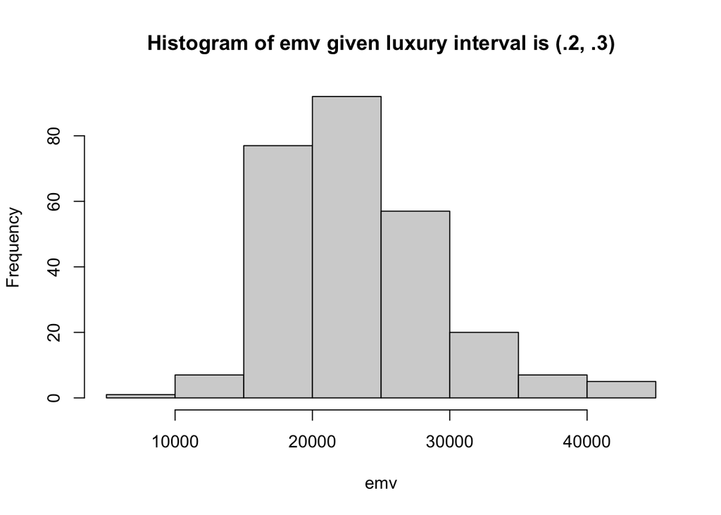

```r
library(DataAnalytics)
data(mvehicles)
cars=mvehicles[mvehicles$bodytype != "Truck",]

luxsubset <- subset(cars, luxury > 0.2 & luxury < 0.3)
hist(luxsubset$emv,
     main = "Histogram of emv given luxury interval is (.2, .3)",
     xlab = "emv")
```

### Q 2, part B

```r
meanemv <- mean(luxsubset$emv)
meanemv
```

```
## [1] 23376.5
```

```r
lwr <- quantile(luxsubset$emv, 0.025)
upr <- quantile(luxsubset$emv, 0.975)
predinterval <- c(lwr, upr)
predinterval
```

```
##     2.5%    97.5%
## 14699.09 38632.34
```

The mean of the conditional distribution in part A is 23376.5. The prediction interval that takes up 95% of the data is [14699.09, 38632.34].

### Q 2, part C

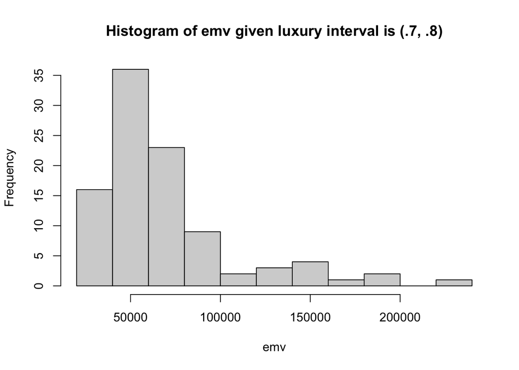

```r
luxsubset2 <- subset(cars, luxury > 0.7 & luxury < 0.8)
hist(luxsubset2$emv,
     main = "Histogram of emv given luxury interval is (.7, .8)",
     xlab = "emv")
```

```r
meanemv2 <- mean(luxsubset2$emv)
meanemv2
```

```
## [1] 68101.87
```

```r
lwr2 <- quantile(luxsubset2$emv, 0.025)
upr2 <- quantile(luxsubset2$emv, 0.975)
predinterval2 <- c(lwr2, upr2)
predinterval2
```

```
##      2.5%     97.5%
##  34254.33 179179.22
```

By observing these two histograms, we find that the histogram in part A is more symmetric than the histogram in part C. The histogram in part C is skewed to the right. The values of the range of x axis of the histogram in part A is smaller than that in part C. Also, we observe that the range of x axis of the histogram in part A is much narrower than that in part C. The distribution of emv is more concentrated as shown by the histogram in part A. On the contrary, the distribution of emv is more scattered as shown by the histogram in part C. Thus, there are greater variability in the values of emv given luxury is in the interval (.7, .8) than the luxury is in the interval (.2, .3).

By comparing the means of the conditional distribution of emv given luxury in these two intervals, we find that it shows lower average emv value given the luxury is in the interval (.2, .3). On the contrary, the mean of the conditional distribution of emv given the interval is (.7, .8) is higher. Moreover, by observing the prediction intervals that takes up 95% of the data given these two intervals, we find that the prediction interval of emv is narrower given the luxury is in the interval (.2, .3) than the prediction interval of emv given the luxury is in the interval (.7, .8). This indicates that there are more variability of emv values when luxury is higher, which shows that it is not too precise to predict emv based on only luxury variable.

### Q 2, part D

Observing the results from part B and part C, it shows that emv is influenced by luxury since we find as the luxury interval increases, the mean values of emv and the prediction intervals increase. However, it is clear that luxury by itself does not provide an accurate prediction of emv because of the wide prediction intervals and obvious variability. Specifically, we find that the 95% prediction intervals for emv ranges from 14,699.09 to 38,632.34 given luxury is in the interval (.2, .3), while in the (0.7, 0.8) interval, the range expands to 34,254.33 to 179,179.22. The prediction intervals are too wide to make accurate prediction. Even though the luxury interval is so small, the prediction interval of emv is too wide. It also suggests that as luxury increases, the values of emv become more scattered and spread. This higher variability in the emv values indicate that there are other factors will influence the emv values. Even though the mean emv increases as the luxury increases (from 23,376.5 to 68,101.87), the histograms’ broad distribution and lack of tight clustering suggest that this relationship might not be clear and definite. It implies that although luxury and emv may be positively correlated, there are still more variable should be considered to predict emv values more accurately. Additional variables or a more intricate model should be taken into account in order to capture the other influences on emv that cannot be explained by luxury alone.

## Question 3 : Optimal Pricing and Elasticities

### Q 3, part A

```r
data(detergent)

model <- lm(q_tide128 ~ p_tide128, data = detergent)
summary(model)
```

```
##
## Call:
## lm(formula = q_tide128 ~ p_tide128, data = detergent)
##
## Residuals:
##     Min      1Q  Median      3Q     Max
## -258.53  -46.95  -16.01   19.11 2048.53
##
## Coefficients:
##             Estimate Std. Error t value Pr(>|t|)
## (Intercept)  661.669     11.223   58.96   <2e-16 ***
## p_tide128    -69.405      1.336  -51.94   <2e-16 ***
## ---
## Signif. codes:  0 '***' 0.001 '**' 0.01 '*' 0.05 '.' 0.1 ' ' 1
##
## Residual standard error: 123.3 on 14743 degrees of freedom
## Multiple R-squared:  0.1547, Adjusted R-squared:  0.1546
## F-statistic:  2697 on 1 and 14743 DF,  p-value: < 2.2e-16
```

```r
elasticity <- coef(summary(model))[2]
elasticity
```

```
## [1] -69.40548
```

```r
confint(model, level = 0.9)
```

```
##                   5 %      95 %
## (Intercept) 643.20814 680.12981
## p_tide128   -71.60381 -67.20716
```

The price elasticity of demand for 128 oz Tide is -69.40548. The 90 percent confidence interval for this elasticity is [-71.60381, -67.20716].

```r
gross_margin <- 0.25
elas <- -1/gross_margin

conf_interval <- c(confint(model, level = 0.9)[2], confint(model, level = 0.9)[4])

if (elas >= conf_interval[1] && elas <= conf_interval[2]) {
  result <- "Fail to reject the null hypothesis: The retailer may be pricing optimally."
} else {
  result <- "Reject the null hypothesis: The retailer is not pricing optimally."
}

result
```

```
## [1] "Reject the null hypothesis: The retailer is not pricing optimally."
```

## Question 4

```r
regression_model <- function(b0, b1, X, sigma) {
  error <- rnorm(length(X), mean = 0, sd = sigma)
  Y <- b0 + b1*X + error
  return(Y)
}
```

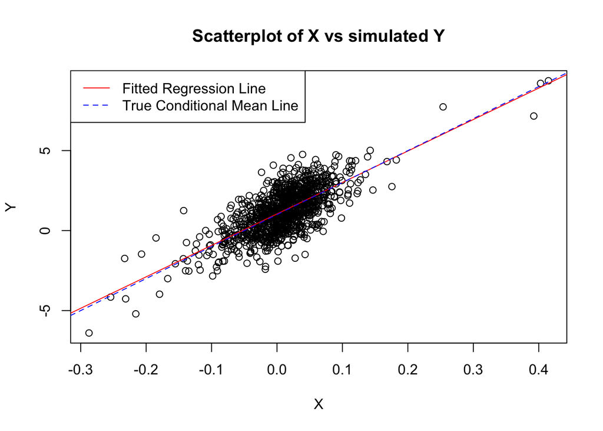

```r
data(marketRf)

b0 = 1
b1 = 20
sigma = 1

x_values <- marketRf$vwretd
y_values <- regression_model(b0, b1, x_values, sigma)


plot(x_values, y_values, main = "Scatterplot of X vs simulated Y",
     xlab = "X", ylab = "Y",)

fitted_model <- lm(y_values ~ x_values)
abline(fitted_model, col = "red", lty = 1)

abline(a = b0, b = b1, col = "blue", lty = 2)


legend("topleft", legend = c("Fitted Regression Line", "True Conditional Mean Line"),
       col = c("red", "blue"), lty=c(1,2))
```

## Question 5

```r
beta0 <- 2
beta1 <- 6
sigmasquare <- 2
```

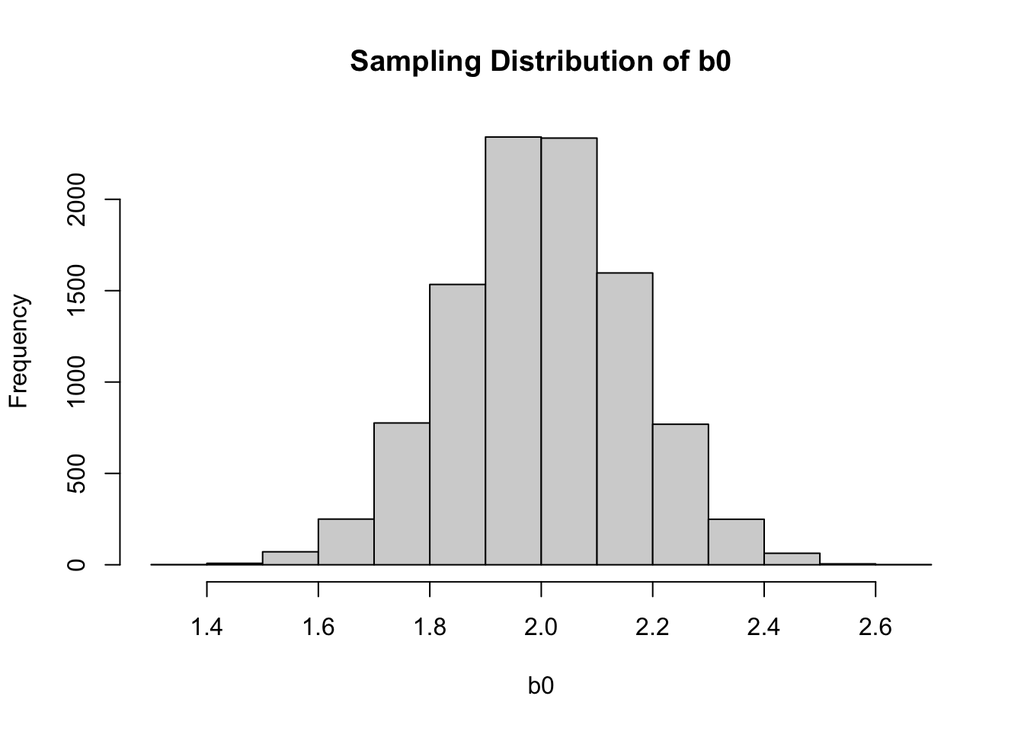

```r
set.seed(2810510)
N <- 300
sigmanew <- sqrt(sigmasquare)

samplesnum <- 10000
beta0samples <- numeric(samplesnum)
beta1samples <- numeric(samplesnum)
for (i in 1:samplesnum){
  x_uniform <- runif(N, min = 0, max = 1)
  y_simulate <- regression_model(beta0, beta1, x_uniform, sigmanew)
  modelnew <- lm(y_simulate ~ x_uniform)
  beta0samples[i] <- coef(modelnew)[1]
  beta1samples[i] <- coef(modelnew)[2]
}

hist(beta0samples, main = "Sampling Distribution of b0",
     xlab = "b0")
```

```r
empb1 <- mean(beta1samples)
empb1
```

```
## [1] 6.00261
```

```r
theob1 <- beta1
theob1
```

```
## [1] 6
```

The simulated value for $\E[b_1]$ is 6.00261 and the theoretical value is 6. These two values are very close.

```r
empvarb1 <- var(beta1samples)
empvarb1
```

```
## [1] 0.07957099
```

```r
xbar <- mean(x_uniform)
deno <- sum((x_uniform - xbar)^2)
theovarb1 <- sigmanew^2 / deno
theovarb1
```

```
## [1] 0.07500658
```

The simulated value for $\var(b_1)$ is 0.07957099. The theoretical value is 0.07500658. These two values are close.

## Question 6